# Prediction Assignment

Sonali Nimkar

May 16, 2016

Also available at: http://rpubs.com/snimkar0924/182113

# Introduction

Using devices such as Jawbone Up, Nike FuelBand, and Fitbit it is now possible to collect a large amount of data about personal activity relatively inexpensively. These type of devices are part of the quantified self movement – a group of enthusiasts who take measurements about themselves regularly to improve their health, to find patterns in their behavior, or because they are tech geeks. One thing that people regularly do is quantify how much of a particular activity they do, but they rarely quantify how well they do it.

In this project, we will use data from accelerometers on the belt, forearm, arm, and dumbell of 6 participants to predict the manner in which they did the exercise.

# Data Preprocessing

Note: `caret`, `ranger`, `corrplot`, `rpart` and `rpart.plot` packages have been loaded silently.

## Download the Data

```r
trainUrl <-
  "https://d396qusza40orc.cloudfront.net/predmachlearn/pml-training.csv"
testUrl <-
  "https://d396qusza40orc.cloudfront.net/predmachlearn/pml-testing.csv"
trainFile <- "./data/pml-training.csv"
testFile  <- "./data/pml-testing.csv"
if (!file.exists("./data"))
{
  dir.create("./data")
}
if (!file.exists(trainFile))
{
  download.file(trainUrl, destfile=trainFile, method="curl")
}
if (!file.exists(testFile))
{
  download.file(testUrl, destfile=testFile, method="curl")
}
```

## Read the Data

```r
trainDat <- read.csv("./data/pml-training.csv")
testDat <- read.csv("./data/pml-testing.csv")
dim(trainDat)
```

```
## [1] 19622   160
```

```r
dim(testDat)
```

```
## [1]  20 160
```

Of the 160 variables in the dataset - the “classe” variable is the one to be predicted.

## Clean the data

In this step, we will clean the data and get rid of observations with missing values as well as some meaningless variables.

```r
sum(complete.cases(trainDat))
```

```
## [1] 406
```

First, we remove columns that contain NA missing values.

```r
trainDat <- trainDat[, colSums(is.na(trainDat)) == 0]
testDat <- testDat[, colSums(is.na(testDat)) == 0]
dim(trainDat)
```

```
## [1] 19622    93
```

```r
dim(testDat)
```

```
## [1] 20 60
```

Next, we get rid of some columns that do not contribute much to the accelerometer measurements.

```r
classe <- trainDat$classe
trainRemove <- grepl("^X|timestamp|window", names(trainDat))
trainDat <- trainDat[, !trainRemove]
trainDat <- trainDat[, sapply(trainDat, is.numeric)]
trainDat$classe <- classe
testRemove <- grepl("^X|timestamp|window", names(testDat))
testDat <- testDat[, !testRemove]
testDat <- testDat[, sapply(testDat, is.numeric)]

dim(trainDat)
```

```
## [1] 19622    53
```

```r
dim(testDat)
```

```
## [1] 20 53
```

```r
colnames(trainDat)
```

```
##  [1] "roll_belt"            "pitch_belt"           "yaw_belt"
##  [4] "total_accel_belt"     "gyros_belt_x"         "gyros_belt_y"
##  [7] "gyros_belt_z"         "accel_belt_x"         "accel_belt_y"
## [10] "accel_belt_z"         "magnet_belt_x"        "magnet_belt_y"
## [13] "magnet_belt_z"        "roll_arm"             "pitch_arm"
## [16] "yaw_arm"              "total_accel_arm"      "gyros_arm_x"
## [19] "gyros_arm_y"          "gyros_arm_z"          "accel_arm_x"
## [22] "accel_arm_y"          "accel_arm_z"          "magnet_arm_x"
## [25] "magnet_arm_y"         "magnet_arm_z"         "roll_dumbbell"
## [28] "pitch_dumbbell"       "yaw_dumbbell"         "total_accel_dumbbell"
## [31] "gyros_dumbbell_x"     "gyros_dumbbell_y"     "gyros_dumbbell_z"
## [34] "accel_dumbbell_x"     "accel_dumbbell_y"     "accel_dumbbell_z"
## [37] "magnet_dumbbell_x"    "magnet_dumbbell_y"    "magnet_dumbbell_z"
## [40] "roll_forearm"         "pitch_forearm"        "yaw_forearm"
## [43] "total_accel_forearm"  "gyros_forearm_x"      "gyros_forearm_y"
## [46] "gyros_forearm_z"      "accel_forearm_x"      "accel_forearm_y"
## [49] "accel_forearm_z"      "magnet_forearm_x"     "magnet_forearm_y"
## [52] "magnet_forearm_z"     "classe"
```

```r
colnames(testDat)
```

```
##  [1] "roll_belt"            "pitch_belt"           "yaw_belt"
##  [4] "total_accel_belt"     "gyros_belt_x"         "gyros_belt_y"
##  [7] "gyros_belt_z"         "accel_belt_x"         "accel_belt_y"
## [10] "accel_belt_z"         "magnet_belt_x"        "magnet_belt_y"
## [13] "magnet_belt_z"        "roll_arm"             "pitch_arm"
## [16] "yaw_arm"              "total_accel_arm"      "gyros_arm_x"
## [19] "gyros_arm_y"          "gyros_arm_z"          "accel_arm_x"
## [22] "accel_arm_y"          "accel_arm_z"          "magnet_arm_x"
## [25] "magnet_arm_y"         "magnet_arm_z"         "roll_dumbbell"
## [28] "pitch_dumbbell"       "yaw_dumbbell"         "total_accel_dumbbell"
## [31] "gyros_dumbbell_x"     "gyros_dumbbell_y"     "gyros_dumbbell_z"
## [34] "accel_dumbbell_x"     "accel_dumbbell_y"     "accel_dumbbell_z"
## [37] "magnet_dumbbell_x"    "magnet_dumbbell_y"    "magnet_dumbbell_z"
## [40] "roll_forearm"         "pitch_forearm"        "yaw_forearm"
## [43] "total_accel_forearm"  "gyros_forearm_x"      "gyros_forearm_y"
## [46] "gyros_forearm_z"      "accel_forearm_x"      "accel_forearm_y"
## [49] "accel_forearm_z"      "magnet_forearm_x"     "magnet_forearm_y"
## [52] "magnet_forearm_z"     "problem_id"
```

Now, the cleaned training data set contains 19622 observations and 53 variables, while the testing data set contains 20 observations and 53 variables.

## Slicing the data

```r
set.seed(400703)
inTrain <- createDataPartition(trainDat$classe, p=0.70, list=F)
trainDat <- trainDat[inTrain, ]
valdnDat <- trainDat[-inTrain, ]

dim(trainDat)
```

```
## [1] 13737    53
```

```r
dim(valdnDat)
```

```
## [1] 4119   53
```

```r
dim(testDat)
```

```
## [1] 20 53
```

# Data Modeling

## Random Forest

We now model the data using the Random Forest modeling technique.

```r
controlRF <- trainControl(method="cv", 5)
modelRF1 <- train(classe ~ ., data=trainDat, method="rf",
                  trControl=controlRF, ntree=25)
modelRF1
```

```
## Random Forest
##
## 13737 samples
##    52 predictor
##     5 classes: 'A', 'B', 'C', 'D', 'E'
##
## No pre-processing
## Resampling: Cross-Validated (5 fold)
## Summary of sample sizes: 10991, 10988, 10990, 10988, 10991
## Resampling results across tuning parameters:
##
##   mtry  Accuracy   Kappa
##    2    0.9854402  0.9815800
##   27    0.9886439  0.9856344
##   52    0.9823102  0.9776224
##
## Accuracy was used to select the optimal model using  the largest value.
## The final value used for the model was mtry = 27.
```

```r
pred1 <- predict(modelRF1, valdnDat)
confusionMatrix(valdnDat$classe, pred1)
```

```
## Confusion Matrix and Statistics
##
##           Reference
## Prediction    A    B    C    D    E
##          A 1157    0    0    0    0
##          B    0  787    0    0    0
##          C    0    0  742    0    0
##          D    0    0    0  672    0
##          E    0    0    0    0  761
##
## Overall Statistics
##
##                Accuracy : 1
##                  95% CI : (0.9991, 1)
##     No Information Rate : 0.2809
##     P-Value [Acc > NIR] : < 2.2e-16
##
##                   Kappa : 1
##  Mcnemar's Test P-Value : NA
##
## Statistics by Class:
##
##                      Class: A Class: B Class: C Class: D Class: E
## Sensitivity            1.0000   1.0000   1.0000   1.0000   1.0000
## Specificity            1.0000   1.0000   1.0000   1.0000   1.0000
## Pos Pred Value         1.0000   1.0000   1.0000   1.0000   1.0000
## Neg Pred Value         1.0000   1.0000   1.0000   1.0000   1.0000
## Prevalence             0.2809   0.1911   0.1801   0.1631   0.1848
## Detection Rate         0.2809   0.1911   0.1801   0.1631   0.1848
## Detection Prevalence   0.2809   0.1911   0.1801   0.1631   0.1848
## Balanced Accuracy      1.0000   1.0000   1.0000   1.0000   1.0000
```

```r
acc1 <- postResample(pred1, valdnDat$classe)
acc1
```

```
## Accuracy    Kappa
##        1        1
```

Prediction on the 20 test cases…

```r
#generating "classe"
result1 <- predict(modelRF1, testDat[, -c(53:54)])
cbind.data.frame(testDat[,1:4], "classe"=result1)
```

```
##    roll_belt pitch_belt yaw_belt total_accel_belt classe
## 1     123.00      27.00    -4.75               20      B
## 2       1.02       4.87   -88.90                4      A
## 3       0.87       1.82   -88.50                5      B
## 4     125.00     -41.60   162.00               17      A
## 5       1.35       3.33   -88.60                3      A
## 6      -5.92       1.59   -87.70                4      E
## 7       1.20       4.44   -87.30                4      D
## 8       0.43       4.15   -88.50                4      B
## 9       0.93       6.72   -93.70                4      A
## 10    114.00      22.40   -13.10               18      A
## 11      0.92       5.94   -92.70                3      B
## 12      1.01       4.96   -87.80                5      C
## 13      0.54       2.45   -88.60                3      B
## 14      0.45       5.02   -87.90                5      A
## 15      5.34      -3.09   -80.30                4      E
## 16      1.65       3.47   -87.00                2      E
## 17    129.00      27.80     1.84               21      A
## 18      0.92       5.31   -93.10                3      B
## 19    123.00      26.70    -2.68               19      B
## 20      1.40       3.20   -88.70                3      B
```

Super!

However, given 52 explanatory variables (and about 13,000 training observations) - creating the RF model using the `train` method in `caret` has been extremely time consuming (on the author’s computer). So we look for alternatives… And use package `ranger` for faster processing of the random forest model.

```r
modelRF2 <-  ranger(classe ~ ., data = trainDat, write.forest = TRUE)
pred2 <- predict(modelRF2, valdnDat)
t2 <- table(predictions(pred2), valdnDat$classe)
t2
```

```
##
##        A    B    C    D    E
##   A 1157    0    0    0    0
##   B    0  787    0    0    0
##   C    0    0  742    0    0
##   D    0    0    0  672    0
##   E    0    0    0    0  761
```

```r
offset <- 5
acc2 <- c("A"=t2[1]/sum(t2[seq(from=1, to=25, by=offset)]),
          "B"=t2[7]/sum(t2[seq(from=2, to=25, by=offset)]),
          "C"=t2[13]/sum(t2[seq(from=3, to=25, by=offset)]),
          "D"=t2[19]/sum(t2[seq(from=4, to=25, by=offset)]),
          "E"=t2[25]/sum(t2[seq(from=5, to=25, by=offset)]))
round(acc2, 4)
```

```
## A B C D E
## 1 1 1 1 1
```

Woah! Super too!

Now using the model on the 20 cases in the testing set …

```r
pred2 <- predict(modelRF2, testDat[,1:52])
result2 <- predictions(pred2)
#printing the 20 predictions & a few columns...
cbind.data.frame(testDat[,1:4], "classe"= result2)
```

```
##    roll_belt pitch_belt yaw_belt total_accel_belt classe
## 1     123.00      27.00    -4.75               20      B
## 2       1.02       4.87   -88.90                4      A
## 3       0.87       1.82   -88.50                5      B
## 4     125.00     -41.60   162.00               17      A
## 5       1.35       3.33   -88.60                3      A
## 6      -5.92       1.59   -87.70                4      E
## 7       1.20       4.44   -87.30                4      D
## 8       0.43       4.15   -88.50                4      B
## 9       0.93       6.72   -93.70                4      A
## 10    114.00      22.40   -13.10               18      A
## 11      0.92       5.94   -92.70                3      B
## 12      1.01       4.96   -87.80                5      C
## 13      0.54       2.45   -88.60                3      B
## 14      0.45       5.02   -87.90                5      A
## 15      5.34      -3.09   -80.30                4      E
## 16      1.65       3.47   -87.00                2      E
## 17    129.00      27.80     1.84               21      A
## 18      0.92       5.31   -93.10                3      B
## 19    123.00      26.70    -2.68               19      B
## 20      1.40       3.20   -88.70                3      B
```

Comparison between predictions from the two models.

```r
table("model1"=result1, "model2"=result2)
```

```
##       model2
## model1 A B C D E
##      A 7 0 0 0 0
##      B 0 8 0 0 0
##      C 0 0 1 0 0
##      D 0 0 0 1 0
##      E 0 0 0 0 3
```

hmm.

# Appendix

Exploring the data.

### Correlation Matrix

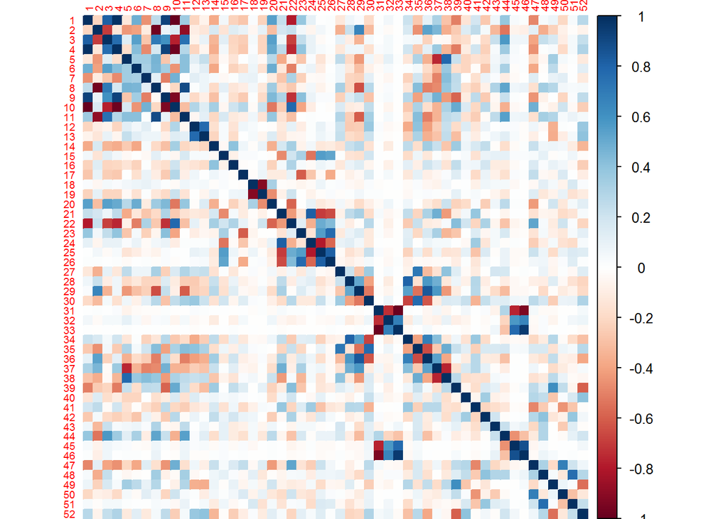

```r
corrPlot <- cor(trainDat[, -length(names(trainDat))])
#anonimize labels for better viewing
attributes(corrPlot)$dimnames[[1]] <- seq(1:(ncol(trainDat)-1))
attributes(corrPlot)$dimnames[[2]] <- seq(1:(ncol(trainDat)-1))
corrplot(corrPlot, method="color", tl.cex=0.6)
```

### Tree Plot

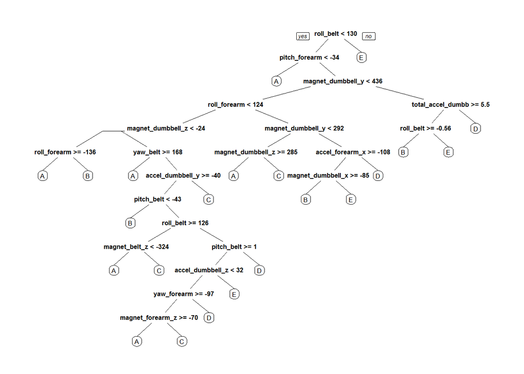

```r
treeModel <- rpart(classe ~ ., data=trainDat, method="class")
prp(treeModel) # fast plot
```